# SDS 192: Homework #2

Sabrina Sayasith

Due: 2/15/16

#### Problem 1

Consider the two data graphics in *The New York Times* article, [“Coming Soon: ‘Taxmageddon’”](http://www.nytimes.com/2012/04/15/sunday-review/coming-soon-taxmageddon.html?_r=0).

1. [Whose Tax Rates Rose or Fell](http://www.nytimes.com/imagepages/2012/04/13/opinion/sunday/0415web-leonhardt.html)
2. [Who Gains Most From Tax Breaks](http://www.nytimes.com/imagepages/2012/04/13/opinion/sunday/0415web-leonhardt2.html)
1. Examine the two data graphics carefully. What story do the graphics tell? Summarize, in one paragraph, what you think the data graphics are designed to convey.

The data graphics define 2 groups through color. Blue represents those who are wealthy and in the top 20% of income distribution and brown represents those in the remaining 80%. The blue group is represented to have more dramatic tax cuts and painted as the main beneficiary of the tax changes. The first graphic that shows tax rates for each group over time depicts a sharp fall in the tax rates of the upper income group. The 2nd graphic depicts the percentage of exclusions the groups are receiving. The blue group is seen to be receiving a large percentage of the exclusions.

2. Evaluate both data graphics in Tufte’s terms. Are the scales appropriate? Consistent? Clearly labelled? Do variable dimensions exceed data dimensions?

The scales seem fine for both graphics. Sizes, color, shape, and scale are consistent throughout. Variable dimensions do not exceed data dimensions. The data ink ratio seems to be high. I think Tufte would find the overall design of the 2 graphics fine. There does not seem to be anything super unescessary or extraneous.

3. What, if anything, is misleading about these graphics?

The first graphic takes into account taxes that very often do not affect the lower income groups - like estate tax. For most states, property that is worth under $1-3 million is exempt. With the second graph, you also have to look at the specific tax breaks. Some of them only apply to those who are wealthier. Also, the year that is being focused on is different between the 2 graphs. The first graphic ends on 2004 and the 2nd graphic focuses on 2011.

#### Problem 2

Choose **one** of the following relatively simple data graphics and answer the following questions. Be sure to indicate which one you picked!

- [Who does not Pay Income Tax?](http://thefuturebuzz.com/2012/09/19/simplicity-with-data-visualization-is-still-best/)
- [WorldÃ¢â¬â¢s Top 10 Best Selling Cigarette Brands, 2004-2007](http://vizwiz.blogspot.com/2009/12/simple-is-better.html)
- [GNPD Usage by Food Categories](http://www.nrsmithdesign.com/wp-content/uploads/2012/10/data-graphic.jpg)
- [NBA Playoff Rings](http://champsring.com/products/pro-basketball-2013)
- [UK University Rankings](http://static.guim.co.uk/sys-images/Guardian/Pix/maps_and_graphs/2010/9/7/1283876186403/Top-universities-graphic-001.jpg)
- [Childhood Obesity in the US](http://www.sparkpe.org/blog/wp-content/uploads/2010/07/childhood-obesity-bmi.gif)
- [Relationship between ages and pyschosocial maturity](http://ars.els-cdn.com/content/image/1-s2.0-S1043276005002602-gr2.jpg)
- [Location of Floating Plastic Trash](http://images.nationalgeographic.com/wpf/media-content/photos/000/816/81694-cb1405449966.jpg)

I chose the UK University Rankings.

1. Identify the visual cues, coordinate system, and scale(s).

The visual cues are color, position, and direction.The coordinate system is cartesian. The x-axis represents time with older dates going to more recent dates from right to left. The years are unequally spaced to make room for the name and country of the institution. There is less y-distance/space between 2008 and 2009 compared to 2010 and 2009 even though both distances should represent a span of 1 year. On the y-axis, from top to bottom there is a straightforward linear numeric ranking. The highest rank, 1, is at the top and it goes down in order to 24 at the bottom. The rankings are equally spaced from each other. Based on the y-axis and x-axis, the scales are numeric and time.

2. How many variables are depicted in the graphic? Explicitly link each variable to a visual cue that you listed above.

There are 5 variables depicted. University name is linked to a line and the line’s y position under 2010. University location is linked with University name and is thus also linked to a line and the line’s y position under 2010. Ranking corresponds to the y position. Year corresponds to the x position. The change in ranking over years corresponds to color. For a university with a rank that goes down from one year to the next, their line color is red. For a rank that stays the same, the line color is orange, and a rank that increases shows a line that is green. Direction also encodes whether a university’s rank went down or up. If the line goes in the up direction, the university’s rank went up from one year to the next. If the line has a downward slope, the university’s rank went down from one year to the next.

3. What would Tufte say about this data graphic? Critique it from his point-of-view.

He would say that ink is wasted in printing the order from 1 to 20 over and over again on the lines. You can start at line 1 and count down yourself to get the ordering. You only need markings in which there is something different about the ordering. In the case of this graphic, there is a rank 24 and the tie for rank 5 that needs to be noted. Also, the change in rank is encoded in both the color and direction of the line. Color can be removed without any loss of information. I wonder what is the point of putting in the country the university is located in? Location is semicoded in the university’s name. Is the graphic trying to make a point about US vs UK universities? Or making a point about the top rankings of universities being dominated by the UK and US? Also, this graphic relies primarily on reds and greens. Red-green color blind people would have difficulty viewing this graphic.

#### Problem 3

Choose **one** of the following collections of data graphics and answer the following questions. Be sure to indicate which one you picked!

- [What is a Data Scientist?](http://static.guim.co.uk/sys-images/Guardian/Pix/pictures/2012/3/2/1330695817953/EMC2-graphic-on-data-scie-008.jpg)
- [Charts that Expain Food in America](http://www.vox.com/a/explain-food-america)
1. Briefly (one paragraph) critique the designer’s choices. Would you have made different choices? Why or why not. > Note: Each link contains a collection of many data graphics, and I don’t expect (or want) you to write a dissertation on each individual graphic. But each collection shares some common stylistic elements. You should comment on a few things that you notice about the design of the collection.

In the “What is a Data Scientist?” set of graphics, each of the graphics compare percentages.

All of the graphics share this black/blue/gray color scheme. However, from graphic to graphic each color means something very different. It gets confusing changing between the graphics and having to change your definition of what blue means.

One graphic uses shades of blue. The darker shade means a higher percentage while lighter shades represent lower percentages. It’s difficult to differentiate between the shades of blue and thus it’s difficult to visualize the differences between the percentages.

With the pie graphs, it is difficult to tell that one portion is bigger than another without the explicit percentage labels. Some of the graphics use bar area to represent the percentages. In “The Source of New Data Science” the 24% bar looks like it can fit 4 of the 12% bar. The 12% bar looks like it can fit 20 of the 2% bar.

Another graphic uses the areas of circles to represent percentages, but the areas look exaggerated compared to the percentages. The 1% circle looks like it can fit into the 5% circle at least 10 times.

Another graphic uses bars, and even though each bar represent sa different percentage, they are all the same size.

The biggest downfall of this set of graphics is inconsistency. I would probably choose bars of the same width stacked up on top of each other for each graphic with each full stack representing 100%. The length of the bars would represent the percentage, the portion of 100%. For color, I’d choose it so that the bar with the largest percentage would be one color across all of the stacks. The next largest percentage would be another color across all of the stacks, and so on.

#### Problem 4

Choose **one** of the more complicated data graphics listed below:

- [Career Paths for Williams College alums](http://web.williams.edu/Mathematics/devadoss/careerpath.html)
- [Wind Map](http://hint.fm/wind/)
- [Obama’s Budget](http://www.nytimes.com/interactive/2012/02/13/us/politics/2013-budget-proposal-graphic.html?_r=1)
- [Mapping the Epigenome](http://www.nytimes.com/imagepages/2008/11/11/science/20081111_EPIGENETICS_GRAPHIC.html)
- [UK Government Spending](http://image.guardian.co.uk/sys-files/Guardian/documents/2011/11/08/Public_spending_2710.pdf)
- Malte Spitz’s [cellphone usage](http://www.zeit.de/datenschutz/malte-spitz-data-retention)
- Wharf 5 [Tide Prediction](http://payload18.cargocollective.com/1/6/194031/2678199/WilfredCastillo_TidePrediction_1C_4_4096.jpg)
- [Wikipedia Changes Map](http://rcmap.hatnote.com/#en,de,ru,ja,es,fr)
- [Programming languages across GitHub](http://infosthetics.com/archives/2014/09/githut_the_universe_of_programming_languages_across_github.html)
- [Causes for breast cancer](http://infosthetics.com/archives/2014/08/the_many_factors_influencing_breast_cancer_incidence.html)
- [CitiBike Rebalancing](http://spatialinformationdesignlab.org/projects/citibike-rebalancing-study)
- [CO2 Emissions](http://image.guardian.co.uk/sys-files/Guardian/documents/2011/02/10/CarbonWeb.pdf)
- [Circos Genomic Data](http://circos.ca/intro/genomic_data/)
- [Jobs Charted by State and Salary](http://flowingdata.com/2014/07/02/jobs-charted-by-state-and-salary/)
1. What story does the data graphic tell? What is the main message that you take away from it?

I chose the “Jobs Charted By State and Salary”. There is one outer giant box representing the universe of all of the jobs it has information on. The box itself is subdivided into different categories of jobs. These category groups are then divided further into more specific jobs. For example, one category is education. Within that category, you can pick out a specific job like “Elementary School Teachers.” Scrolling over that specific job, you can get the median salary and the number of people who have that job. For a big picture view, this graphic tells us about the job landscape for a specific state or the entirety of the US. You can quickly glance are and see what kind of jobs have the largest number of people working them by first noticing which categories take up the most area. You can then see in each category which specific job has the most people. On the other hand, you can also use the slidey bar to pick a median annual salary to figure out which categories of jobs tend to have higher salaries. You will see that some categories will be covered in green, meaning all of these have higher median salaries than the one you set, while some categories will only be comprised of white boxes. You can adjust the median salary higher to see within those categories which specific jobs make the most. Flipping through the states, you can see which categories are more prevelant and “big”. You can compare states and see which area would be the “best” for you depending on what you want to do as a job.

2. Can the data graphic be described in terms of the taxonomy laid out in *MDSR*? If so, list the visual cues, coordinate system, and scales(s) as you did in Problem 2(a). If not, describe the feature of this data graphic that lies outside of that taxonomy.

Visual cues: Area(# of people), color(median salary of job > median salary set OR median salary of job < median salary set), position(category + job) Coordinate System: Cartesian Scale(s): Categorical(job type), Numeric(size of boxes/position)

3. Critique and/or praise the visualization choices made by the designer. Do they work? Are they misleading? Thought-provoking? Brilliant? Are there things that you would have done differently? Justify your response.

I think the choice to use only green and white makes the graphic very clear. These are the jobs that make more money, and these are the jobs that make less. With some of the box areas, it is difficult to determine if one is larger than another. Though I suppose for the big picture, you just care if one category or job is significantly larger than another. It’s nice being able to check and uncheck “Show Job Categories” so you can choose to focus on either the larger categories or the specific jobs. Keeping the larger box the same size while alternating the sizes of the category and job boxes helps keep everything in perspective. I’m glad the category boxes were seperated by thicker lines.It’s simple, effective, and doesn’t get in the way of any of the other information. Overall, I think the designer did a really good job. There is nothing confusing about the graphics, and there is no extraneous information or ink. It would be interesting to compare more than 1 state side by side.

#### Problem 5

1. Using the `Marriage` data set, create an informative and meaningful data graphic.

```r
require(mosaic)
require(mosaicData)
head(Marriage)
```

```
##   bookpageID  appdate ceremonydate delay     officialTitle person      dob
## 1   B230p539 10/29/96      11/9/96    11    CIRCUIT JUDGE   Groom  4/11/64
## 2   B230p677 11/12/96     11/12/96     0 MARRIAGE OFFICIAL  Groom   8/6/64
## 3   B230p766 11/19/96     11/27/96     8 MARRIAGE OFFICIAL  Groom  2/20/62
## 4   B230p892  12/2/96      12/7/96     5          MINISTER  Groom  5/20/56
## 5   B230p994  12/9/96     12/14/96     5          MINISTER  Groom 12/14/66
## 6  B230p1209 12/26/96     12/26/96     0 MARRIAGE OFFICIAL  Groom  2/21/70
##        age     race prevcount prevconc hs college dayOfBirth        sign
## 1 32.60274    White         0     <NA> 12       7      102.0       Aries
## 2 32.29041    White         1  Divorce 12       0      219.0         Leo
## 3 34.79178 Hispanic         1  Divorce 12       3       51.5      Pisces
## 4 40.57808    Black         1  Divorce 12       4      141.0      Gemini
## 5 30.02192    White         0     <NA> 12       0      348.5 Saggitarius
## 6 26.86301    White         1     <NA> 12       0       52.5      Pisces
```

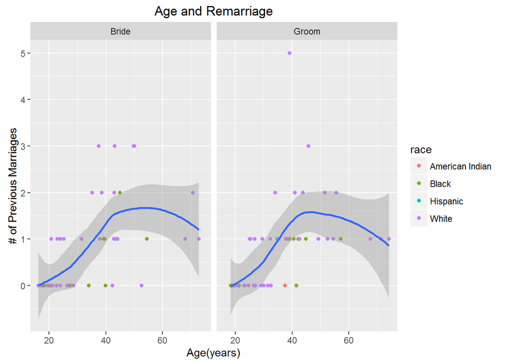

```r
 p <- ggplot(Marriage, aes(x = age, y = prevcount))
 p + geom_point(aes(color = race)) + geom_smooth() + facet_wrap(~person) +labs(title = "Age and Remarriage", x="Age(years)", y = "# of Previous Marriages" )
```

Age and remarriage trends are the same for both brides and grooms.

2. Identify each of the visual cues that you are using, and describe how they are related to each variable. Color represents race. Using a cartesian coordinate system: x-position seperates gender. x-position is age. The larger the x-position, the older the person. y-position: # of previous marriages
3. Now, create a data graphic with at least **five** variables (either quantitative or categorical) encoded. Do not worry about making your visualization meaningful – just try to encode five variables into one plot.

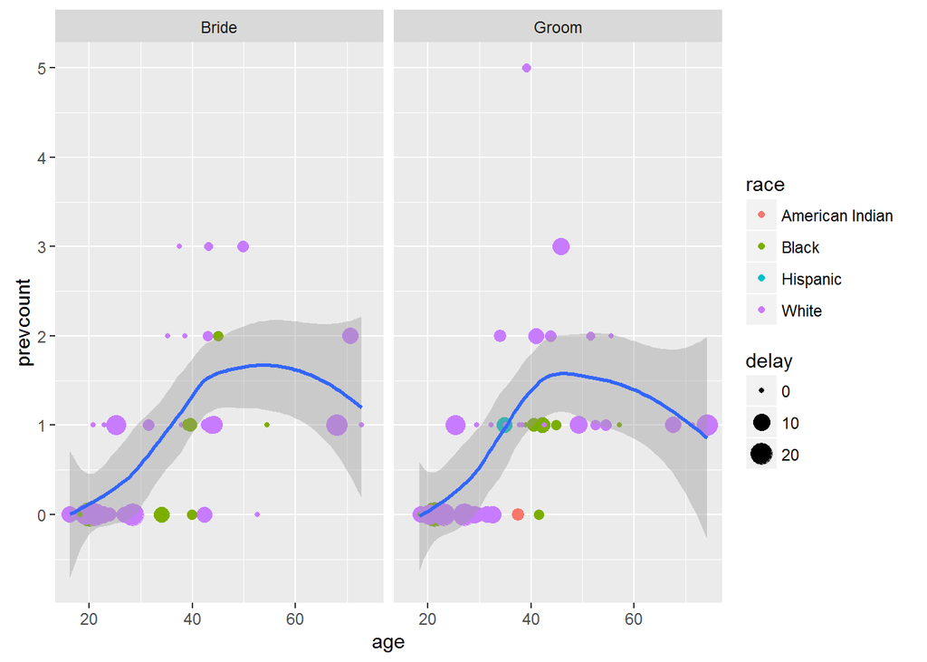

```r
 p <- ggplot(Marriage, aes(x = age, y = prevcount))
 p + geom_point(aes(color = race, size = delay)) + geom_smooth() + facet_wrap(~person)
```

#### Problem 6

Using the `CPS85` data set from the `mosaic` package:

1. Make this data graphic

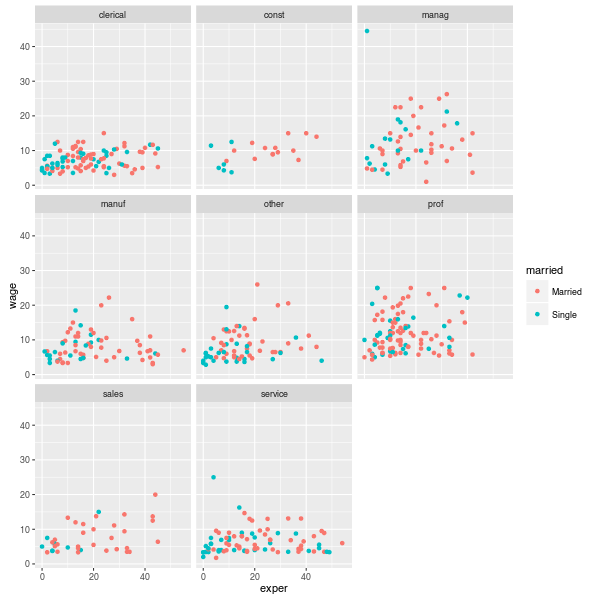

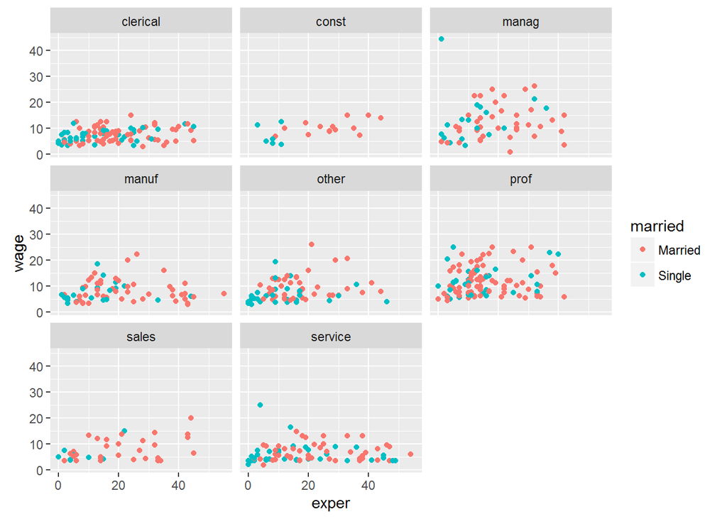

```r
 p <- ggplot(CPS85, aes(x = exper, y = wage))
 p + geom_point(aes(color = married)) + facet_wrap(~sector)
```

2. Make this data graphic

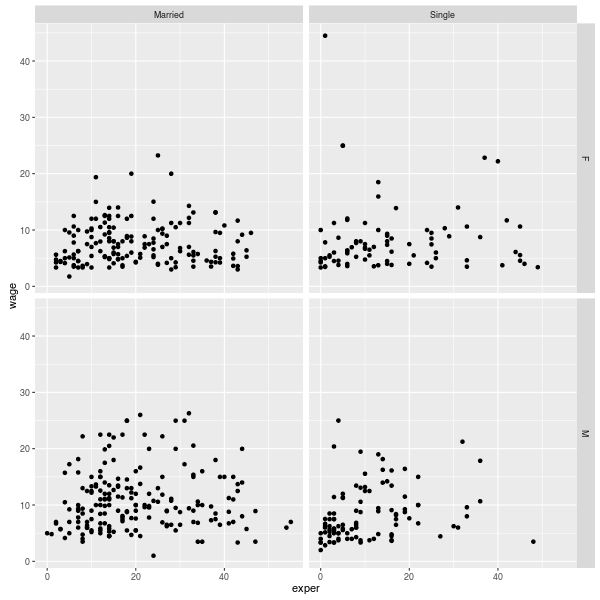

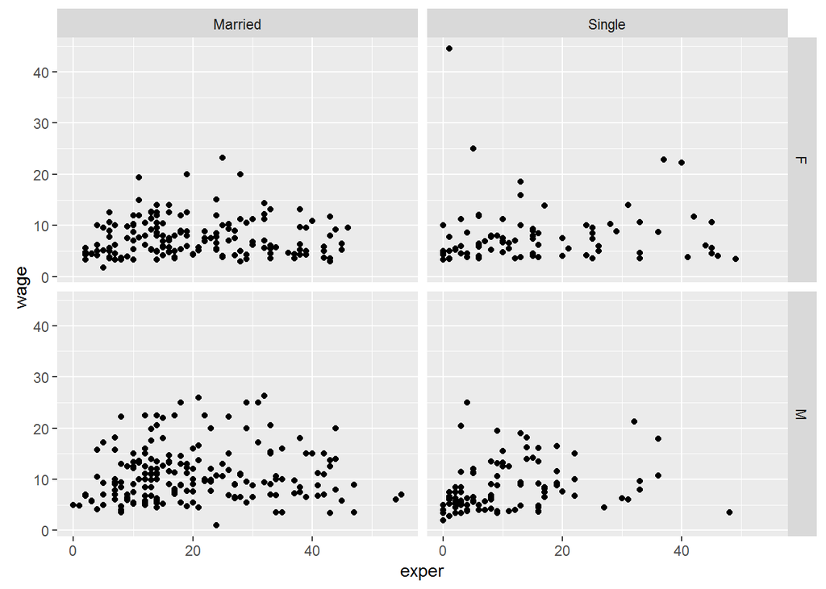

```r
 p <- ggplot(CPS85, aes(x = exper, y = wage))
 p + geom_point() + facet_grid(sex~married)
```